# Exploring the BRFSS data

## Setup

### Load packages

```r
library(tidyverse)
```

### Load data

```r
load("brfss2013.RData")
```

## Part 1: Data

The data is collected for non-institutionalized adults 18 or older living in the United States of America by randomly contacting subjects by phone, household land-line or cell-phone. cell-phone interviews are collected for adults indicating they live in a private residence or college housing.

Data are collected annually for all 50 states, the District of Columbia, Puerto Rico, Guam and the U.S. Virgin. And are collected at limited points in time for American Samoa, Federated States of Micronesia and Palau.

As the data are randomly collected sample from the full population of the U.S., results should be generalizable to the full adult population. The collection of demographic information provides the ability to stratify the data to identify possible confounding factors such as geographic location, ethnicity related factors, etc. However, as some collection is done via cell phone there is no way to validate that the subjects interviewed lives at a private residence or college housing which could lead to some possible out of scope subjects getting included.

In addition to data collected about the subjects, data about the condition, time and other environmental factors are collected. There are also a large number of calculated fields consolidating information from multiple questions or inferring new information based on other responses.

## Part 2: Research questions

**Research question 1:** Is there a relationship between a subjects weight and the likelihood of having had a heart attack or having been diagnosed with cardiovascular disease?

This information can be used to help people determine their risk of hear attack based on their own weight.

**Research question 2:** Are Veterans more likely to suffer from depression than non-veterans?

Can be used by the veteran administration to determine how much to allocate for mental health services.

It can also be used to help veterans who might be suffering from a depressive disorder to understand they are not alone so they will be more likely to get treated.

**Research question 3:** Is there a relationship between Sugar Drinks use and rates of pre-diabetes and diabetes?

For health care professionals, if a correlation is identified this can be used guide patients and possibly reduce instances of diabetes or for people who are already diagnosed, if there is a correlation changing their consumption could aid in treating the condition.

## Part 3: Exploratory data analysis

### Question 1

**Is there a relationship between a subjects weight and the likelihood of having had a heart attack or having been diagnosed with cardiovascular disease?**

Step 1, get the metrics needed to answer the question, these are a subjects weight, height and cardiovascular history. As a subjects weight is relative to their height I will be using (BMI)[https://www.cdc.gov/healthyweight/assessing/bmi/index.html] (X_bmi), which is a ratio of height to weight instead of just weight.

Only keep data where we know the subject is a resident of the state they were in when the subject was interviewed and that they live in a private residence.

```r
hrt_data_1 <- brfss2013 %>%
  select(X_state, pvtresd1, stateres, sex,
         cvdinfr4, cvdcrhd4, htm4, wtkg3, X_bmi5) %>%
  filter(pvtresd1 == "Yes" &
           stateres == "Yes")

summary(hrt_data_1)
```

```
##           X_state       pvtresd1     stateres         sex         cvdinfr4
##  Florida      : 27374   Yes:360089   Yes:360089   Male  :134452   Yes : 24849
##  Kansas       : 16031   No :     0                Female:225635   No  :333246
##  Nebraska     : 12972                             NA's  :     2   NA's:  1994
##  Massachusetts: 12151
##  Maryland     : 11143
##  Minnesota    : 10547
##  (Other)      :269871
##  cvdcrhd4           htm4            wtkg3           X_bmi5
##  Yes : 25049   Min.   :   1.0   Min.   :    1   Min.   :   1
##  No  :331310   1st Qu.: 160.0   1st Qu.: 6577   1st Qu.:2374
##  NA's:  3730   Median : 168.0   Median : 7711   Median :2690
##                Mean   : 168.6   Mean   : 7966   Mean   :2790
##                3rd Qu.: 175.0   3rd Qu.: 9072   3rd Qu.:3086
##                Max.   :2469.0   Max.   :29030   Max.   :9511
##                NA's   :5101     NA's   :16043   NA's   :19194
```

Remove unusually (probably erroneous) tall and short subjects and cases where the height is NA.

```r
hrt_data_1 <- hrt_data_1 %>%
  filter(!is.na(htm4) & htm4 < 500 & htm4 > 10)
```

Remove cases where the weight is NA and convert to decimal. It is stored as an integer with the last 2 digits being values to the right of the decimal point.

```r
hrt_data_1 <- hrt_data_1 %>%
  filter(!is.na(wtkg3)) %>%
  mutate(wtkg3 = wtkg3 / 100)

summary(hrt_data_1)
```

```
##           X_state       pvtresd1     stateres         sex         cvdinfr4
##  Florida      : 26162   Yes:342122   Yes:342122   Male  :132078   Yes : 24001
##  Kansas       : 15242   No :     0                Female:210044   No  :316315
##  Nebraska     : 12331                                             NA's:  1806
##  Massachusetts: 11277
##  Maryland     : 10489
##  Minnesota    :  9946
##  (Other)      :256675
##  cvdcrhd4           htm4           wtkg3            X_bmi5
##  Yes : 24256   Min.   : 91.0   Min.   : 22.68   Min.   :1202
##  No  :314422   1st Qu.:160.0   1st Qu.: 65.77   1st Qu.:2374
##  NA's:  3444   Median :168.0   Median : 77.11   Median :2690
##                Mean   :168.7   Mean   : 79.70   Mean   :2790
##                3rd Qu.:175.0   3rd Qu.: 90.72   3rd Qu.:3086
##                Max.   :236.0   Max.   :290.30   Max.   :9511
##                                                 NA's   :1232
```

I’d say this looks good but I’m distressed by the large number of people over 100kg, that’s, at best, really sad. We still have some NA’s in BMI

Next let’s drop the NA’s from Cardiovascular disease indicators and make them boolean values. Also, set a single cardio value which indicates whether an subject has either had a heart attack or been diagnosed with caritvascular disease.

I’ve also decided to calculate the BMI as picking apart the encoded one seems overly complicated and there are more NA’s than I would expect.

```r
hrt_data_1 <- hrt_data_1 %>%
  filter(!is.na(cvdinfr4) & !is.na(cvdcrhd4)) %>%
  mutate(cvdinfr4=cvdinfr4=="Yes",
         cvdcrhd4=cvdcrhd4=="Yes",
         cardio=cvdinfr4 | cvdcrhd4,
         bmi=wtkg3/(htm4/100)^2,
         pvtresd1=NULL,
         stateres=NULL,
         X_bmi5=NULL)

summary(hrt_data_1)
```

```
##           X_state           sex          cvdinfr4        cvdcrhd4
##  Florida      : 25682   Male  :129922   Mode :logical   Mode :logical
##  Kansas       : 15022   Female:207277   FALSE:314389    FALSE:313280
##  Nebraska     : 12108                   TRUE :22810     TRUE :23919
##  Massachusetts: 11143
##  Maryland     : 10390
##  Minnesota    :  9855
##  (Other)      :252999
##       htm4           wtkg3          cardio             bmi
##  Min.   : 91.0   Min.   : 22.68   Mode :logical   Min.   :  6.417
##  1st Qu.:160.0   1st Qu.: 65.77   FALSE:302158    1st Qu.: 23.741
##  Median :168.0   Median : 77.11   TRUE :35041     Median : 26.837
##  Mean   :168.7   Mean   : 79.67                   Mean   : 27.880
##  3rd Qu.:175.0   3rd Qu.: 90.72                   3rd Qu.: 30.799
##  Max.   :236.0   Max.   :290.30                   Max.   :121.903
##
```

Add a factor indicating the relative level of weight based on the BMI. The threshold values are based on the definitions on the above lined CDC BMI site. I combined, low and normal weight and the 2 high obese categories to keep things simple.

```r
bmi_factors = c("low_to_normal", "overweight", "obese",
                "severely to very severly obeses")
hrt_data_1 <- hrt_data_1 %>%
  mutate(bmi_category=case_when(
    bmi < 25 ~ bmi_factors[1],
    bmi < 30 ~ bmi_factors[2],
    bmi < 35 ~ bmi_factors[3],
    TRUE ~ bmi_factors[4]),
    bmi_category=factor(bmi_category,levels=bmi_factors, ordered=TRUE))
```

```r
hrt_data_1 %>%
  group_by(sex, cardio, bmi_category) %>%
  summarize(mean_bmi=mean(bmi),
            count=length(bmi)

  )
```

```
## # A tibble: 16 x 5
## # Groups:   sex, cardio [4]
##    sex    cardio bmi_category                    mean_bmi count
##    <fct>  <lgl>  <ord>                              <dbl> <int>
##  1 Male   FALSE  low_to_normal                       22.7 30356
##  2 Male   FALSE  overweight                          27.3 49169
##  3 Male   FALSE  obese                               32.0 21938
##  4 Male   FALSE  severely to very severly obeses     39.7 10708
##  5 Male   TRUE   low_to_normal                       22.7  4121
##  6 Male   TRUE   overweight                          27.4  7445
##  7 Male   TRUE   obese                               32.1  3994
##  8 Male   TRUE   severely to very severly obeses     39.7  2191
##  9 Female FALSE  low_to_normal                       22.1 77236
## 10 Female FALSE  overweight                          27.4 59890
## 11 Female FALSE  obese                               32.2 31123
## 12 Female FALSE  severely to very severly obeses     40.6 21738
## 13 Female TRUE   low_to_normal                       22.0  5435
## 14 Female TRUE   overweight                          27.4  5540
## 15 Female TRUE   obese                               32.2  3455
## 16 Female TRUE   severely to very severly obeses     41.1  2860
```

Accounting for the subjects sex, what are the counts of people with and without cardiovascular conditions by BMI category and what percent of each group has cardiovascular conditions.

```r
as.data.frame(table(hrt_data_1[,c("cardio", "bmi_category", "sex")])) %>%
  tidyr::pivot_wider(names_from=cardio, names_prefix="cardio_", values_from=Freq) %>%
  mutate(pct_cardio=(cardio_TRUE / (cardio_FALSE + cardio_TRUE)) * 100)
```

```
## # A tibble: 8 x 5
##   bmi_category                    sex    cardio_FALSE cardio_TRUE pct_cardio
##   <fct>                           <fct>         <int>       <int>      <dbl>
## 1 low_to_normal                   Male          30356        4121      12.0
## 2 overweight                      Male          49169        7445      13.2
## 3 obese                           Male          21938        3994      15.4
## 4 severely to very severly obeses Male          10708        2191      17.0
## 5 low_to_normal                   Female        77236        5435       6.57
## 6 overweight                      Female        59890        5540       8.47
## 7 obese                           Female        31123        3455       9.99
## 8 severely to very severly obeses Female        21738        2860      11.6
```

There appears to be a positive correlation between BMI and cardiovascular conditions for both men and women.

**Research quesion 2:**

**Are Veterans more likely to suffer from depression than non-veterans?**

Get the required data. Filter for only subjects who indicated a private residence and were residents of the state they were in during the interview. Also remove any cases where sex, veteran status and whether they had been diagnosed with depression were not answered.

```r
vet_data_1 <- brfss2013 %>%
  select(X_state, pvtresd1, stateres, sex,
         veteran3, addepev2) %>%
  filter(pvtresd1 == "Yes" &
           stateres == "Yes",
         !is.na(sex),
         !is.na(veteran3),
         !is.na(addepev2))

summary(vet_data_1)
```

```
##           X_state       pvtresd1     stateres         sex         veteran3
##  Florida      : 27173   Yes:358006   Yes:358006   Male  :133503   Yes: 47578
##  Kansas       : 15950   No :     0                Female:224503   No :310428
##  Nebraska     : 12895
##  Massachusetts: 12052
##  Maryland     : 11078
##  Minnesota    : 10489
##  (Other)      :268369
##  addepev2
##  Yes: 68663
##  No :289343
##
##
##
##
##
```

```r
vet_data_1 %>%
  select(sex, veteran3, addepev2) %>%
  table() %>%
  as.data.frame() %>%
  tidyr::pivot_wider(names_from=addepev2,
                     names_prefix="Depressed_",
                     values_from=Freq) %>%
  mutate(pct_depressed=(Depressed_Yes/(Depressed_Yes + Depressed_No))*100)
```

```
## # A tibble: 4 x 5
##   sex    veteran3 Depressed_Yes Depressed_No pct_depressed
##   <fct>  <fct>            <int>        <int>         <dbl>
## 1 Male   Yes               6281        37397          14.4
## 2 Female Yes               1056         2844          27.1
## 3 Male   No               12403        77422          13.8
## 4 Female No               48923       171680          22.2
```

**Research quesion 3:**

**Is there a relationship between Sugar Drinks use and rates of pre-diabetes and diabetes?**

Get the required data. Filter for only subjects who indicated a private residence and were residents of the state they were in during the interview. Also remove any cases where the subject reported diabetes diagnosis during pregnancy and where there was no answer (NA) for sugar sweetened drinks.

Add together pop and non-pop sugar sweetened drinks to 1 value.

```r
# Convert drinks count to monthly equivalent
sugarCount <- function(value) {
  v <- lapply(value, function(x) {
    if ( x > 300 ) return((x - 300) / 30)
    if ( x > 200 ) return((x - 200) / 7)
    if ( x > 100 ) return(x - 100)
    return(x)
  })

  return(unlist(v))
}


pop_data_1 <- brfss2013 %>%
  select(X_state, pvtresd1, stateres, sex,
         prediab1, diabage2,
         ssbsugar, ssbfrut2) %>%
  filter(pvtresd1 == "Yes" &
           stateres == "Yes" &
           !is.na(sex) &
           !is.na(prediab1) & prediab1 != "Yes, during pregnancy" &
           !is.na(ssbsugar),
         !is.na(ssbfrut2)) %>%
  mutate(prediab1=prediab1 == "Yes",
         ssbs=sugarCount(ssbsugar),
         ssbf=sugarCount(ssbfrut2),
         sugar_drinks_per_day=ssbs+ssbf,
  )

summary(pop_data_1)
```

```
##            X_state      pvtresd1    stateres        sex         prediab1
##  Minnesota     : 8416   Yes:47059   Yes:47059   Male  :17294   Mode :logical
##  Kentucky      : 6226   No :    0               Female:29765   FALSE:42101
##  South Carolina: 5676                                          TRUE :4958
##  Connecticut   : 4622
##  Mississippi   : 3933
##  West Virginia : 3352
##  (Other)       :14834
##     diabage2        ssbsugar        ssbfrut2          ssbs
##         :47058   Min.   :  0.0   Min.   :  0.0   Min.   : 0.00000
##  10     :    1   1st Qu.:  0.0   1st Qu.:  0.0   1st Qu.: 0.00000
##  .b     :    0   Median :101.0   Median :  0.0   Median : 0.03333
##  1      :    0   Mean   :125.1   Mean   :105.4   Mean   : 0.35829
##  11     :    0   3rd Qu.:301.0   3rd Qu.:203.0   3rd Qu.: 0.28571
##  12     :    0   Max.   :399.0   Max.   :399.0   Max.   :30.00000
##  (Other):    0
##       ssbf         sugar_drinks_per_day
##  Min.   : 0.0000   Min.   : 0.0000
##  1st Qu.: 0.0000   1st Qu.: 0.0000
##  Median : 0.0000   Median : 0.1429
##  Mean   : 0.2965   Mean   : 0.6548
##  3rd Qu.: 0.2857   3rd Qu.: 1.0000
##  Max.   :30.0000   Max.   :31.0000
##
```

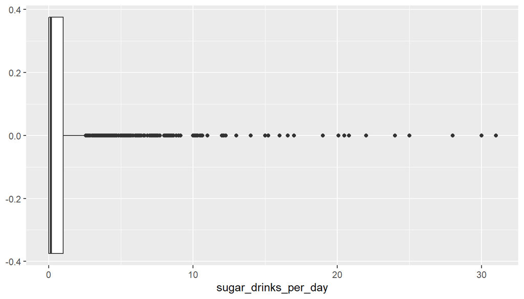

```r
pop_data_1 %>%
  ggplot(aes(x=sugar_drinks_per_day)) +
  geom_boxplot()
```

After filtering for pop, only 1 diabetes subject remained. So, we will look at pre-diabetes diagnosis only.

```r
drinkRate <- function(dr, factors) {

  v <- lapply(dr, function(x) {
    if (x == 0) return(factors[1])
    if (x <= 0.5) return(factors[2])
    if (x <= 1) return(factors[3])
    if (x <= 3) return(factors[4])
    return(factors[5])
  })

  return(factor(unlist(v), levels=factors))
}

pop_data_2 <- pop_data_1 %>%
  mutate(drink_cat=drinkRate(sugar_drinks_per_day,
                             c("none", "every other day", "1 a day",
                               "more than 1 less than 3 a day", "3 or more a day")))

summary(pop_data_2)
```

```
##            X_state      pvtresd1    stateres        sex         prediab1
##  Minnesota     : 8416   Yes:47059   Yes:47059   Male  :17294   Mode :logical
##  Kentucky      : 6226   No :    0               Female:29765   FALSE:42101
##  South Carolina: 5676                                          TRUE :4958
##  Connecticut   : 4622
##  Mississippi   : 3933
##  West Virginia : 3352
##  (Other)       :14834
##     diabage2        ssbsugar        ssbfrut2          ssbs
##         :47058   Min.   :  0.0   Min.   :  0.0   Min.   : 0.00000
##  10     :    1   1st Qu.:  0.0   1st Qu.:  0.0   1st Qu.: 0.00000
##  .b     :    0   Median :101.0   Median :  0.0   Median : 0.03333
##  1      :    0   Mean   :125.1   Mean   :105.4   Mean   : 0.35829
##  11     :    0   3rd Qu.:301.0   3rd Qu.:203.0   3rd Qu.: 0.28571
##  12     :    0   Max.   :399.0   Max.   :399.0   Max.   :30.00000
##  (Other):    0
##       ssbf         sugar_drinks_per_day                         drink_cat
##  Min.   : 0.0000   Min.   : 0.0000      none                         :14671
##  1st Qu.: 0.0000   1st Qu.: 0.0000      every other day              :17226
##  Median : 0.0000   Median : 0.1429      1 a day                      : 6207
##  Mean   : 0.2965   Mean   : 0.6548      more than 1 less than 3 a day: 7084
##  3rd Qu.: 0.2857   3rd Qu.: 1.0000      3 or more a day              : 1871
##  Max.   :30.0000   Max.   :31.0000
##
```

```r
pop_data_2 %>%
  group_by(sex, prediab1, drink_cat) %>%
  summarize(count=n()) %>%
  tidyr::pivot_wider(names_from=prediab1,
                     names_prefix="diagnosed_pre_diabetes_",
                     values_from=count) %>%
  mutate(percent_pre_diabetes=(diagnosed_pre_diabetes_TRUE /
                                 (diagnosed_pre_diabetes_TRUE + diagnosed_pre_diabetes_FALSE)) * 100)
```

```
## # A tibble: 10 x 5
## # Groups:   sex [2]
##    sex    drink_cat      diagnosed_pre_diab~ diagnosed_pre_dia~ percent_pre_dia~
##    <fct>  <fct>                        <int>              <int>            <dbl>
##  1 Male   none                          3660                576            13.6
##  2 Male   every other d~                5764                674            10.5
##  3 Male   1 a day                       2348                253             9.73
##  4 Male   more than 1 l~                2872                275             8.74
##  5 Male   3 or more a d~                 795                 77             8.83
##  6 Female none                          9377               1058            10.1
##  7 Female every other d~                9627               1161            10.8
##  8 Female 1 a day                       3246                360             9.98
##  9 Female more than 1 l~                3529                408            10.4
## 10 Female 3 or more a d~                 883                116            11.6
```

For males, there is a mostly negative correlation between number of sugary drinks and diagnosis of pre-diabetes. For women the ratio of population in each group is relatively close. Results are at best inconclusive.